# DATA 607 Week 9 Assignment : Web APIs

Fan Xu

10/27/2019

# I. Assignment Overview

The New York Times web site provides a rich set of APIs, as described here: https://developer.nytimes.com/apis(https://developer.nytimes.com/apis)

You’ll need to start by signing up for an API key.

Your task is to choose one of the New York Times APIs, construct an interface in R to read in the JSON data, and transform it into an R DataFrame.

# II. Load Package

```r
library(tidyverse)
library(httr)
library(jsonlite)
library(stringr)
library(kableExtra)
library(ggplot2)
library(forcats)
```

# III. Set filter

I will use Article Search API to look up articles. The date range is the whole year 2019. Search results from the first 5 pages will be downloaded.

```r
base_url = 'https://api.nytimes.com/svc/search/v2/articlesearch.json'
start_date <- "20190101"
end_date <- "20191231"
first_page = 1
last_page = 5
```

# IV. Read data and Convert to DataFrame

## a. Create a dataframe to consolidate outputs from all pagination in scope.

```r
df_json <- data.frame(
         pub_date=character(),
         headline=character(),
         abstract=character(),
         lead_paragraph=character(),
         author=character(),
         type_of_material=character(),
         source=character(),
         section_name=character(),
         word_count=integer(),
         web_url=character(),
         stringsAsFactors = FALSE
)
```

## b. Get data, perfrom tidying and produce final output

1. set a for loop to get contents from the first 5 pages of search result. `api_key` is hidden.
2. `GET` function from package `httr` is used to get data from data source.
3. `fromJSON` function from package `jsonlite` is used to convert json files to data frames.
4. store data from each search page to data frame `df_temp`
5. consolidate `df_temp` from each search page into data frame `df_json` as final output.

```r
for (page in first_page:last_page){
url = str_c(base_url,
            '?begin_date=',start_date,
            '&end_date=',end_date,
            '&offset=',page,
            '&api-key=',api_key,
            sep = '')

articles <- GET(url)

#http_status(articles)

stop_for_status(articles)

df_temp <- fromJSON(url) %>%
 .$response %>%
 .$doc %>%
  mutate(headline = headline$main) %>%
  mutate(byline = byline$original) %>%
  mutate(byline = str_remove(byline, '^By ')) %>%
  mutate(pub_date = as.Date(pub_date)) %>%
  rename(author = byline) %>%
  select(pub_date,
         headline,
         abstract,
         lead_paragraph,
         author,
         type_of_material,
         source,
         section_name,
         word_count,
         web_url)


df_json <- rbind(df_json,df_temp)
#print(c("Current Page: ", page))
Sys.sleep(2)
df_json
}
```

```r
df_json %>%
  kable() %>%
  kable_styling() %>%
  scroll_box(width = "810px", height = '500px')
```

| pub_date | headline | abstract | lead_paragraph | author | type_of_material | source | section_name | word_count | web_url |
| --- | --- | --- | --- | --- | --- | --- | --- | --- | --- |
| 2019-02-15 | The Federal Debt Is Rising. Concern Is Not. | The United States government now owes more than $22 trillion, but debt reduction is no longer a top issue in Washington. | WASHINGTON — The federal debt ticked past $22 trillion this week, a record that comes despite continued economic growth, but neither political party appears to be making a priority of debt reduction. | Binyamin Appelbaum | News | The New York Times | U.S. | 1093 | https://www.nytimes.com/2019/02/15/us/politics/national-debt-trump.html |
| 2019-02-13 | A Bargain Store Has Britons Asking: Can You Really Pop the Question With Plastic? | The British bargain store Poundland offered a one-pound engagement ring for Valentine’s Day. It sold 20,000 of them before the holiday arrived. | LONDON — He had thought of everything: a home-cooked, candlelit dinner, a romantic playlist, a declaration of love and a ring. | Ceylan Yeginsu | News | The New York Times | World | 823 | https://www.nytimes.com/2019/02/13/world/europe/britain-poundland-ring.html |
| 2019-02-14 | Film Club: ‘After Parkland, Turning Trauma Into Change’ | In honor of the anniversary of the Parkland shooting, a film about coping with trauma and making a difference. | How can we channel pain into fuel for change? | Natalie Proulx | News | The New York Times | The Learning Network | 480 | https://www.nytimes.com/2019/02/14/learning/film-club-after-parkland-turning-trauma-into-change.html |
| 2019-02-13 | Takeaways From a Wide-Ranging State of the State | Wednesday: How Gov. Gavin Newsom took on his predecessor and dismissed the president; new transparency on police shootings; and a tiny love story. | Good morning. | Jill Cowan | briefing | The New York Times | U.S. | 1359 | https://www.nytimes.com/2019/02/13/us/california-today-gavin-newsom-state-of-the-state.html |
| 2019-02-15 | A Novel About the Life and Times of the Photographer Lee Miller | Whitney Scharer’s “The Age of Light” tells the story of the journalist and model who was often overshadowed by her lover and collaborator Man Ray. | THE AGE OF LIGHT By Whitney Scharer | Lauren Elkin | Review | The New York Times | Books | 1321 | https://www.nytimes.com/2019/02/15/books/review/whitney-scharer-age-light.html |
| 2019-02-14 | F.B.I. Opens Inquiry Into Ryan Adams’s Explicit Communications With an Underage Fan | The musician denies that he had inappropriate online sexual communications “with someone he knew was underage.” Agents from the Crimes Against Children Squad will seek to interview the woman. | The F.B.I. is looking into whether the singer-songwriter Ryan Adams, 44, committed a crime by engaging in sexually explicit communications with an underage fan, according to a law enforcement official… | Joe Coscarelli and William K. Rashbaum | News | The New York Times | Arts | 897 | https://www.nytimes.com/2019/02/14/arts/music/fbi-ryan-adams.html |
| 2019-02-11 | The Neuroscience of ‘Rock-a-Bye Baby’ | A new study shows it works for adult sleep, too. | Want to fall effortlessly into profound slumber and sleep like a baby? Everyone knows that infants can be lulled to sleep by gentle rocking. Well, now it seems that what works for babies works for adu… | Richard A. Friedman | Op-Ed | The New York Times | Opinion | 868 | https://www.nytimes.com/2019/02/10/opinion/sleep-neuroscience.html |
| 2019-02-15 | Amazon and New York Unions Had ‘Productive Meeting,’ Then Came a Shock | Labor groups aiming to organize a Staten Island warehouse were in talks with the company a day before it abandoned plans for a Queens headquarters. | When Amazon announced Thursday that it was abandoning plans for an additional corporate headquarters in New York, no one was more surprised than the union leaders who were in talks with the company th… | Natalie Kitroeff | News | The New York Times | Business Day | 703 | https://www.nytimes.com/2019/02/14/business/economy/amazon-union-cuomo.html |
| 2019-02-14 | Felipe González: We Must Not Fail the Venezuelan People | To restore democracy in the Latin American nation, foreign powers need to step aside and let the regional stakeholders resolve the crisis. | MADRID — Venezuela has been part of my life, both politically and personally, for over four decades. I was a friend of Rómulo Betancourt, the founding father of Venezuelan democracy; of Carlos Andrés … | Felipe González | Op-Ed | The New York Times | Opinion | 1012 | https://www.nytimes.com/2019/02/14/opinion/felipe-gonzalez-venezuelan.html |
| 2019-02-14 | ‘Parkland: Inside Building 12’ Review: Recounting the Attack in Painful Detail | This documentary on the Florida school shooting makes the massacre immediate in a way that sometimes gets lost in news coverage or political debates. | For roughly the first 50 minutes of “Parkland: Inside Building 12,” students and teachers recall last year’s attack at Marjory Stoneman Douglas High School in harrowing detail: who heard what and when… | Ben Kenigsberg | Review | The New York Times | Movies | 276 | https://www.nytimes.com/2019/02/14/movies/parkland-inside-building-12-review.html |
| 2019-02-14 | Learning With: ‘Parkland: A Year After the School Shooting That Was Supposed to Change Everything’ | One year later, what have we learned from the shooting at Marjory Stoneman Douglas High School? | Before reading the article: | Jeremy Engle | News | The New York Times | The Learning Network | 1029 | https://www.nytimes.com/2019/02/14/learning/learning-with-parkland-a-year-after-the-school-shooting-that-was-supposed-to-change-everything.html |
| 2019-02-14 | F.B.I. Investigates Suspicious Fire at Planned Parenthood Clinic in Missouri | The bureau is looking into possible federal civil rights violations in connection with a fire at a center in Columbia, Mo., on Sunday. | The F.B.I. has opened an investigation into a fire at a Planned Parenthood clinic in Missouri last weekend that the Columbia Police Department said was suspicious. | Emily S. Rueb | News | The New York Times | U.S. | 367 | https://www.nytimes.com/2019/02/13/us/planned-parenthood-fire-missouri.html |
| 2019-02-13 | Trump Says South Korea Is Paying $500 Million More for U.S. Troops. The Deal Says Otherwise. | Contrary to President Trump’s comments, South Korea is increasing its contribution to defense costs by $70 million, American and South Korean officials said. | SEOUL, South Korea — South Koreans were left flustered on Wednesday after President Trump asserted that he had made their government pay $500 million more to help cover the cost of maintaining America… | Choe Sang-Hun | News | The New York Times | World | 598 | https://www.nytimes.com/2019/02/13/world/asia/trump-south-korea.html |
| 2019-02-11 | How Russia Undermined Over 30 Years of Nuclear Arms Control | Since 1987, a treaty with Moscow to limit midrange missile deployment has boosted trans-Atlantic security. But Russia has been cheating, and is fielding missiles banned by the compact. | Why did Russia argue that the United States should keep the Intermediate-Range Nuclear Forces Treaty intact and then recently declare its own suspension of the treaty? After all, it has deployed many … | Kay Bailey Hutchison | Op-Ed | The New York Times | Opinion | 847 | https://www.nytimes.com/2019/02/10/opinion/russia-inf-treaty.html |
| 2019-02-13 | Manafort Lied After Plea Deal, Judge Says | A federal judge found that President Trump’s former campaign chairman was untruthful about several topics, potentially leading to a longer sentence. | WASHINGTON — A federal judge ruled on Wednesday that Paul Manafort, President Trump’s former campaign chairman, had breached his plea agreement by lying multiple times to prosecutors after pledging to… | Sharon LaFraniere | News | The New York Times | U.S. | 967 | https://www.nytimes.com/2019/02/13/us/politics/manafort-mueller.html |
| 2019-02-13 | NASA’s Opportunity Rover Dies on Mars | Fifteen years and 28 miles on the red planet. | Fifteen years and 28 miles on the red planet. | Jonathan Corum | Interactive Feature | The New York Times | Science | 0 | https://www.nytimes.com/interactive/2019/02/13/science/opportunity-rover-mars-map.html |
| 2019-02-14 | A Poem for Richard E. Grant, Portrayer of Lovable Lowlifes | The American poet D. A. Powell shares an ode to the actor’s mischievous character Jack Hock in “Can You Ever Forgive Me?” | This Valentine’s Day, T asked five writers to compose a love letter (of sorts) to an actor or fictional character who has been nominated — or, in one case, passed over — this year for the 91st Academy… | D. A. Powell | News | The New York Times | T Magazine | 203 | https://www.nytimes.com/2019/02/14/t-magazine/richard-e-grant-poem.html |
| 2019-02-13 | Maria Ressa, Philippine Journalist Critical of Rodrigo Duterte, Is Released After Arrest | Her detention in a digital libel case involving her online news site, Rappler, comes amid a crackdown on the news media by the president. | It’s a scene that Maria Ressa, a co-founder of an online news start-up critical of President Rodrigo Duterte of the Philippines, has grown accustomed to. | Alexandra Stevenson | News | The New York Times | World | 793 | https://www.nytimes.com/2019/02/13/world/asia/maria-ressa-arrested.html |
| 2019-02-14 | Covering the Lives of Veterans, Revered but Often Forgotten | I took the veterans affairs beat at the end of last year and quickly found that veterans — and those who care for them — are eager to share experiences and to engage. | Times Insider explains who we are and what we do, and delivers behind-the-scenes insights into how our journalism comes together. | Jennifer Steinhauer | News | The New York Times | Reader Center | 753 | https://www.nytimes.com/2019/02/14/reader-center/veterans-affairs-health-war.html |
| 2019-02-14 | Some Bathroom Postings | John E. Bennett and Jeff Chen collaborate once again. | THURSDAY PUZZLE — I’m way ahead of you. I’ve already asked the editors what happened to the hearts, chocolate and flowers — Happy Valentine’s Day, by the way — and I was told that there were no Valent… | Deb Amlen | News | The New York Times | Crosswords & Games | 640 | https://www.nytimes.com/2019/02/13/crosswords/daily-puzzle-2019-02-14.html |
| 2019-02-14 | Kashmir Suffers From the Worst Attack There in 30 Years | The suicide bomb that killed at least 40 soldiers in a convoy of Indian paramilitary forces will likely raise tensions between India and Pakistan. | AWANTIPORA, Kashmir — A vehicle filled with explosives rammed into a convoy of Indian paramilitary forces on a busy highway in the Indian-controlled part of Kashmir on Thursday, killing at least 40 so… | Sameer Yasir and Maria Abi-Habib | News | The New York Times | World | 835 | https://www.nytimes.com/2019/02/14/world/asia/pulwama-attack-kashmir.html |
| 2019-02-14 | 7 Things to Do With Your Kids in N.Y.C. This Weekend | Our guide to cultural events in New York City for children and teenagers happening this weekend and in the week ahead. | Our guide to cultural events in New York City for children and teenagers happening this weekend and in the week ahead. | Laurel Graeber | News | The New York Times | Arts | 885 | https://www.nytimes.com/2019/02/14/arts/nyc-this-weekend-childrens-events.html |
| 2019-02-14 | Mike Pence Lashes European Allies for Their Stance on Iran | The U.S. vice president demanded that Britain, France and Germany “stand by us” and quit their efforts to help Tehran sidestep American sanctions. | WARSAW — Vice President Mike Pence used an American-convened conference on Middle East security to lash out at Washington’s three closest European allies on Thursday, accusing them of trying “to break… | David E. Sanger and Katie Rogers | News | The New York Times | World | 1246 | https://www.nytimes.com/2019/02/14/world/europe/pompeo-pence-us-iran.html |
| 2019-02-15 | Las principales noticias del viernes | La cárcel del Chapo, emergencia nacional, diagnósticos por computadora y fórmulas para el amor: lo que está sucediendo en América Latina y el mundo. | ¡Ya es viernes! Bienvenido al boletín diario de The New York Times en Español. Si aún no estás suscrito, puedes darte de alta en este enlace. | Por Marina Franco | briefing | The New York Times | Universal | 1678 | https://www.nytimes.com/es/2019/02/14/universal/es/el-times-noticias-viernes.html |
| 2019-02-14 | Border Security, Foreign Aid and a Raise for Federal Workers: What You Need to Know About the Spending Package | Seven spending bills, including a sweeping border security package, passed through both chambers on Thursday, in time to avert a second shutdown. | WASHINGTON — The $333 billion spending package Congress passed on Thursday will probably keep the government fully funded through the end of September. But it also delivers the most stinging rebuke of… | Emily Cochrane and Catie Edmondson | News | The New York Times | U.S. | 934 | https://www.nytimes.com/2019/02/14/us/politics/congress-trump-border-deal-wall.html |
| 2019-02-15 | Jacob deGrom Wants to Stay in Queens. What More Do the Mets Need to Know? | The Mets have still not offered their Cy Young Award-winning ace a contract extension despite having a clear picture of his talent and value. | PORT ST. LUCIE, Fla. — Jacob deGrom was the best in the world at his job last season. For that, the Mets gave him a raise of almost $10 million. | Tyler Kepner | News | The New York Times | Sports | 935 | https://www.nytimes.com/2019/02/14/sports/jacob-degrom-mets-contract.html |
| 2019-02-14 | M.L.S. Commissioner Don Garber Gets Five-Year Contract Extension | Garber, who has overseen a wave of expansion that has more than doubled the size of the league since he took over in 1999, will remain through the 2023 season. | Don Garber, who in two decades as commissioner has overseen a wave of expansion that has more than doubled the size of Major League Soccer, has signed a five-year contract extension that will keep him… | Andrew Das | News | The New York Times | Sports | 401 | https://www.nytimes.com/2019/02/14/sports/mls-don-garber.html |
| 2019-02-15 | Facebook Fine Could Total Billions if F.T.C. Talks Lead to a Deal | The social media company is in discussions with regulators over claims that it violated a 2011 consent decree regarding user privacy. | WASHINGTON — Facebook and the Federal Trade Commission are discussing a settlement over privacy violations that could amount to a record, multibillion-dollar fine, according to three people with knowl… | Cecilia Kang | News | The New York Times | Technology | 425 | https://www.nytimes.com/2019/02/14/technology/facebook-ftc-settlement.html |
| 2019-02-14 | Raymond K. Price Jr., 88, a Key Nixon Speechwriter, Is Dead | A former newsman, Mr. Price wrote drafts for the president’s Inaugural Addresses and his resignation speech, lending a moderate voice. | Raymond K. Price Jr., a cerebral, pipe-smoking speechwriter for President Richard M. Nixon who helped write the first and last words of his presidency, his Inaugural Addresses and his resignation spee… | Douglas Martin | Obituary (Obit) | The New York Times | Obituaries | 1553 | https://www.nytimes.com/2019/02/14/obituaries/raymond-k-price-jr-dead.html |
| 2019-02-15 | Burning Man, Seeking to Change ‘Convenience Culture,’ Boots Camp for Wealthy | The chief executive said she had warned 12 camps and disinvited one from the annual event where attendees create music and art in the Nevada desert. | Burning Man’s chief executive has disinvited one camp for wealthy attendees and warned a dozen others as it outlines steps the organization has taken to return the event to its egalitarian roots, acco… | Laura M. Holson | News | The New York Times | Business Day | 714 | https://www.nytimes.com/2019/02/15/business/burning-man-tickets.html |
| 2019-02-15 | The Federal Debt Is Rising. Concern Is Not. | The United States government now owes more than $22 trillion, but debt reduction is no longer a top issue in Washington. | WASHINGTON — The federal debt ticked past $22 trillion this week, a record that comes despite continued economic growth, but neither political party appears to be making a priority of debt reduction. | Binyamin Appelbaum | News | The New York Times | U.S. | 1093 | https://www.nytimes.com/2019/02/15/us/politics/national-debt-trump.html |
| 2019-02-13 | A Bargain Store Has Britons Asking: Can You Really Pop the Question With Plastic? | The British bargain store Poundland offered a one-pound engagement ring for Valentine’s Day. It sold 20,000 of them before the holiday arrived. | LONDON — He had thought of everything: a home-cooked, candlelit dinner, a romantic playlist, a declaration of love and a ring. | Ceylan Yeginsu | News | The New York Times | World | 823 | https://www.nytimes.com/2019/02/13/world/europe/britain-poundland-ring.html |
| 2019-02-14 | Film Club: ‘After Parkland, Turning Trauma Into Change’ | In honor of the anniversary of the Parkland shooting, a film about coping with trauma and making a difference. | How can we channel pain into fuel for change? | Natalie Proulx | News | The New York Times | The Learning Network | 480 | https://www.nytimes.com/2019/02/14/learning/film-club-after-parkland-turning-trauma-into-change.html |
| 2019-02-13 | Takeaways From a Wide-Ranging State of the State | Wednesday: How Gov. Gavin Newsom took on his predecessor and dismissed the president; new transparency on police shootings; and a tiny love story. | Good morning. | Jill Cowan | briefing | The New York Times | U.S. | 1359 | https://www.nytimes.com/2019/02/13/us/california-today-gavin-newsom-state-of-the-state.html |
| 2019-02-15 | A Novel About the Life and Times of the Photographer Lee Miller | Whitney Scharer’s “The Age of Light” tells the story of the journalist and model who was often overshadowed by her lover and collaborator Man Ray. | THE AGE OF LIGHT By Whitney Scharer | Lauren Elkin | Review | The New York Times | Books | 1321 | https://www.nytimes.com/2019/02/15/books/review/whitney-scharer-age-light.html |
| 2019-02-14 | F.B.I. Opens Inquiry Into Ryan Adams’s Explicit Communications With an Underage Fan | The musician denies that he had inappropriate online sexual communications “with someone he knew was underage.” Agents from the Crimes Against Children Squad will seek to interview the woman. | The F.B.I. is looking into whether the singer-songwriter Ryan Adams, 44, committed a crime by engaging in sexually explicit communications with an underage fan, according to a law enforcement official… | Joe Coscarelli and William K. Rashbaum | News | The New York Times | Arts | 897 | https://www.nytimes.com/2019/02/14/arts/music/fbi-ryan-adams.html |
| 2019-02-11 | The Neuroscience of ‘Rock-a-Bye Baby’ | A new study shows it works for adult sleep, too. | Want to fall effortlessly into profound slumber and sleep like a baby? Everyone knows that infants can be lulled to sleep by gentle rocking. Well, now it seems that what works for babies works for adu… | Richard A. Friedman | Op-Ed | The New York Times | Opinion | 868 | https://www.nytimes.com/2019/02/10/opinion/sleep-neuroscience.html |
| 2019-02-15 | Amazon and New York Unions Had ‘Productive Meeting,’ Then Came a Shock | Labor groups aiming to organize a Staten Island warehouse were in talks with the company a day before it abandoned plans for a Queens headquarters. | When Amazon announced Thursday that it was abandoning plans for an additional corporate headquarters in New York, no one was more surprised than the union leaders who were in talks with the company th… | Natalie Kitroeff | News | The New York Times | Business Day | 703 | https://www.nytimes.com/2019/02/14/business/economy/amazon-union-cuomo.html |
| 2019-02-14 | Felipe González: We Must Not Fail the Venezuelan People | To restore democracy in the Latin American nation, foreign powers need to step aside and let the regional stakeholders resolve the crisis. | MADRID — Venezuela has been part of my life, both politically and personally, for over four decades. I was a friend of Rómulo Betancourt, the founding father of Venezuelan democracy; of Carlos Andrés … | Felipe González | Op-Ed | The New York Times | Opinion | 1012 | https://www.nytimes.com/2019/02/14/opinion/felipe-gonzalez-venezuelan.html |
| 2019-02-14 | ‘Parkland: Inside Building 12’ Review: Recounting the Attack in Painful Detail | This documentary on the Florida school shooting makes the massacre immediate in a way that sometimes gets lost in news coverage or political debates. | For roughly the first 50 minutes of “Parkland: Inside Building 12,” students and teachers recall last year’s attack at Marjory Stoneman Douglas High School in harrowing detail: who heard what and when… | Ben Kenigsberg | Review | The New York Times | Movies | 276 | https://www.nytimes.com/2019/02/14/movies/parkland-inside-building-12-review.html |
| 2019-02-14 | Learning With: ‘Parkland: A Year After the School Shooting That Was Supposed to Change Everything’ | One year later, what have we learned from the shooting at Marjory Stoneman Douglas High School? | Before reading the article: | Jeremy Engle | News | The New York Times | The Learning Network | 1029 | https://www.nytimes.com/2019/02/14/learning/learning-with-parkland-a-year-after-the-school-shooting-that-was-supposed-to-change-everything.html |
| 2019-02-14 | F.B.I. Investigates Suspicious Fire at Planned Parenthood Clinic in Missouri | The bureau is looking into possible federal civil rights violations in connection with a fire at a center in Columbia, Mo., on Sunday. | The F.B.I. has opened an investigation into a fire at a Planned Parenthood clinic in Missouri last weekend that the Columbia Police Department said was suspicious. | Emily S. Rueb | News | The New York Times | U.S. | 367 | https://www.nytimes.com/2019/02/13/us/planned-parenthood-fire-missouri.html |
| 2019-02-13 | Trump Says South Korea Is Paying $500 Million More for U.S. Troops. The Deal Says Otherwise. | Contrary to President Trump’s comments, South Korea is increasing its contribution to defense costs by $70 million, American and South Korean officials said. | SEOUL, South Korea — South Koreans were left flustered on Wednesday after President Trump asserted that he had made their government pay $500 million more to help cover the cost of maintaining America… | Choe Sang-Hun | News | The New York Times | World | 598 | https://www.nytimes.com/2019/02/13/world/asia/trump-south-korea.html |
| 2019-02-11 | How Russia Undermined Over 30 Years of Nuclear Arms Control | Since 1987, a treaty with Moscow to limit midrange missile deployment has boosted trans-Atlantic security. But Russia has been cheating, and is fielding missiles banned by the compact. | Why did Russia argue that the United States should keep the Intermediate-Range Nuclear Forces Treaty intact and then recently declare its own suspension of the treaty? After all, it has deployed many … | Kay Bailey Hutchison | Op-Ed | The New York Times | Opinion | 847 | https://www.nytimes.com/2019/02/10/opinion/russia-inf-treaty.html |
| 2019-02-13 | Manafort Lied After Plea Deal, Judge Says | A federal judge found that President Trump’s former campaign chairman was untruthful about several topics, potentially leading to a longer sentence. | WASHINGTON — A federal judge ruled on Wednesday that Paul Manafort, President Trump’s former campaign chairman, had breached his plea agreement by lying multiple times to prosecutors after pledging to… | Sharon LaFraniere | News | The New York Times | U.S. | 967 | https://www.nytimes.com/2019/02/13/us/politics/manafort-mueller.html |
| 2019-02-13 | NASA’s Opportunity Rover Dies on Mars | Fifteen years and 28 miles on the red planet. | Fifteen years and 28 miles on the red planet. | Jonathan Corum | Interactive Feature | The New York Times | Science | 0 | https://www.nytimes.com/interactive/2019/02/13/science/opportunity-rover-mars-map.html |
| 2019-02-14 | A Poem for Richard E. Grant, Portrayer of Lovable Lowlifes | The American poet D. A. Powell shares an ode to the actor’s mischievous character Jack Hock in “Can You Ever Forgive Me?” | This Valentine’s Day, T asked five writers to compose a love letter (of sorts) to an actor or fictional character who has been nominated — or, in one case, passed over — this year for the 91st Academy… | D. A. Powell | News | The New York Times | T Magazine | 203 | https://www.nytimes.com/2019/02/14/t-magazine/richard-e-grant-poem.html |
| 2019-02-13 | Maria Ressa, Philippine Journalist Critical of Rodrigo Duterte, Is Released After Arrest | Her detention in a digital libel case involving her online news site, Rappler, comes amid a crackdown on the news media by the president. | It’s a scene that Maria Ressa, a co-founder of an online news start-up critical of President Rodrigo Duterte of the Philippines, has grown accustomed to. | Alexandra Stevenson | News | The New York Times | World | 793 | https://www.nytimes.com/2019/02/13/world/asia/maria-ressa-arrested.html |
| 2019-02-14 | Covering the Lives of Veterans, Revered but Often Forgotten | I took the veterans affairs beat at the end of last year and quickly found that veterans — and those who care for them — are eager to share experiences and to engage. | Times Insider explains who we are and what we do, and delivers behind-the-scenes insights into how our journalism comes together. | Jennifer Steinhauer | News | The New York Times | Reader Center | 753 | https://www.nytimes.com/2019/02/14/reader-center/veterans-affairs-health-war.html |
| 2019-02-14 | Some Bathroom Postings | John E. Bennett and Jeff Chen collaborate once again. | THURSDAY PUZZLE — I’m way ahead of you. I’ve already asked the editors what happened to the hearts, chocolate and flowers — Happy Valentine’s Day, by the way — and I was told that there were no Valent… | Deb Amlen | News | The New York Times | Crosswords & Games | 640 | https://www.nytimes.com/2019/02/13/crosswords/daily-puzzle-2019-02-14.html |

# V. Extra: Plots for Analysis

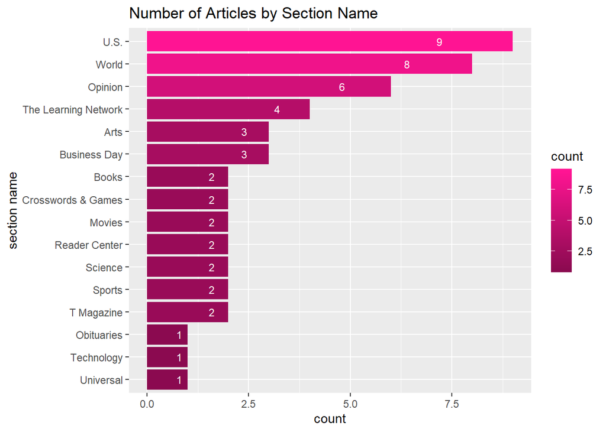

```r
ggplot(data=df_json, aes(x=fct_rev(fct_infreq(section_name)), y=..count.., fill = ..count..))+
  geom_bar(stat='count')+
  geom_text(stat = 'count', aes(label=..count..),size = 3, color= 'white',position = position_stack(vjust = 0.8))+
  scale_fill_gradient(low = 'deeppink4', high = 'deeppink1')+
  xlab('section name')+
  ggtitle('Number of Articles by Section Name')+
  coord_flip()
```

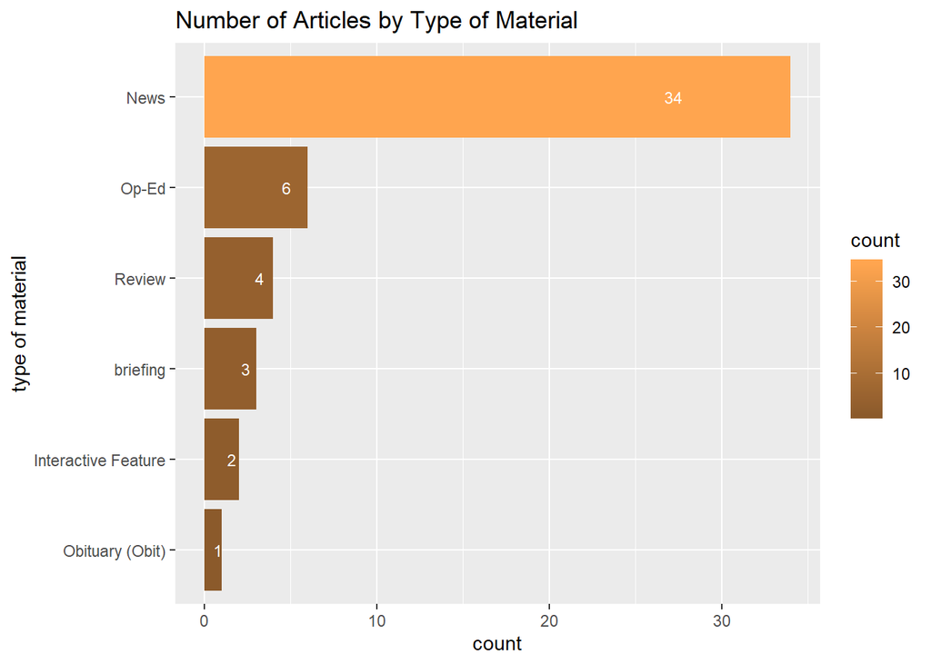

```r
ggplot(data=df_json, aes(x=fct_rev(fct_infreq(type_of_material)), y=..count.., fill = ..count..))+
  geom_bar(stat='count')+
  geom_text(stat = 'count', aes(label=..count..),size = 3, color= 'white',position = position_stack(vjust = 0.8))+
  scale_fill_gradient(low = 'tan4', high = 'tan1')+
  xlab('type of material')+
  ggtitle('Number of Articles by Type of Material')+
  coord_flip()
```

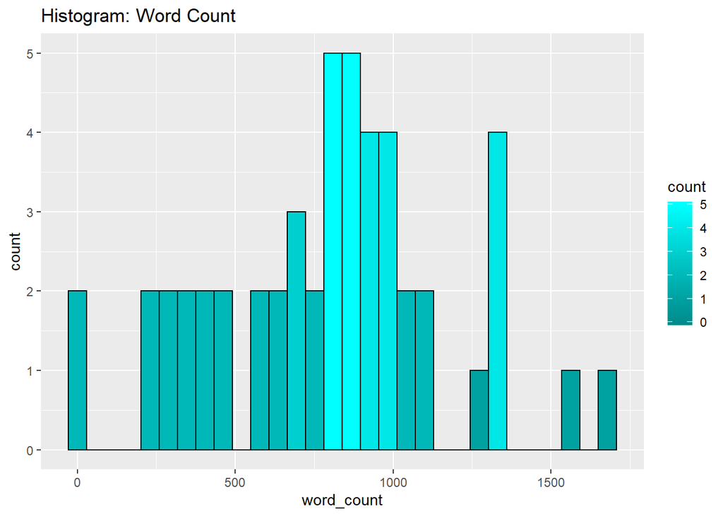

```r
ggplot(data=df_json, aes(x=word_count, fill=..count..))+
  geom_histogram(bins=30,color="black")+
  scale_fill_gradient(low = 'cyan4', high = 'cyan1')+
  ggtitle('Histogram: Word Count')
```